# DMO in BHSCT Macular Service - Analysis Notes

David M Wright - d.wright@qub.ac.uk

Document compiled: 2021-09-06

R version 4.0.3 (2020-10-10)

# 1 Introduction

This analysis is of Electronic Medical Records (EMR) from the Belfast Health and Social Care Trust Macular Service. The aims are to describe the pattern of anti-VEGF injection intervals among patients receiving treatment for Diabetic Macular Oedema (DMO). Of particular interest are those patients that were able to have injection intervals consistently extended over 12 weeks duration.

# 2 Cohort construction

## 2.1 Pre-processing

The data structure is defined in the file `Novartis DMO Study - Data Dictionary v1.1.xls` and a total of 18 separate pipe delimited files were provided (Table 2.1). Data were extracted on 2021-03-31.

Table 2.1: Description of input data files.

| Table number | Table name | Rows | Columns | Description |
| --- | --- | --- | --- | --- |
| 1 | DMOClinicalFindings | 90975 | 12 | A table of all clinical findings at any time for any patient within the cohort |
| 2 | DMOCoPathology | 25949 | 8 | A table of co-pathologies recorded at any time for any patient within the cohort |
| 3 | DMODiabeticDiagnosis | 6022 | 10 | A list of diabetic status data for any patient within the cohort |
| 4 | DMODiagnoses | 45279 | 13 | A table of all diagnoses recorded in the system at any time for any patient within the cohort |
| 5 | DMODRAssessment | 19068 | 16 | A list of DR Assessment outcomes for any patient within the cohort |
| 6 | DMODRGrading | 65285 | 11 | A list of the DR Grading outcomes for any patient within the cohort |
| 7 | DMOEncounters | 92312 | 16 | A table of all related clinical encounters for any patient within the cohort |
| 8 | DMOInjections | 20305 | 15 | A table of ocular injections at any time for any patient within the cohort |
| 9 | DMOInvestigations | 1671 | 8 | A table of requested investigations at any time for any patient within the cohort |
| 10 | DMOIOP | 87514 | 9 | A table of intraocular pressure (IOP) measurements recorded at any time for any patient within the cohort |
| 11 | DMOMedicalHistory | 793979 | 8 | A list of recorded medical history at any time for any patient within the cohort |
| 12 | DMOMedication | 27644 | 19 | A table of medications recorded or prescribed at any time for any patient within the cohort |
| 13 | DMOOperativeComplications | 27728 | 9 | A table of perioperative complications for any patient within the cohort |
| 14 | DMOPatientDetails | 4330 | 9 | A table of patients included within the cohort |
| 15 | DMOPostOperativeComplications | 225715 | 9 | A table of post-operative ocular complications for any patient within the cohort |
| 16 | DMOSurgery | 27808 | 15 | A list of ocular procedures for any patient within the cohort |
| 17 | DMOSurgeryIndications | 27782 | 9 | A list of indications for surgery (primary diagnosis) for any patient within the cohort |
| 18 | DMOVisualAcuity | 156983 | 18 | A list of all visual acuity (VA) measurements recorded at any time for any patient within the cohort |

The following steps were taken to pre-process the data:

### 2.1.1 DMOVisualAcuity table

- Conversion of visual acuity measurements to both ETDRS and logMAR formats.

### 2.1.2 DMOInjections table

- Removed 155 injections that were not for anti-VEGF agents.
- Removed 9 duplicate injection entries.
- Added visual acuity measurements to the corresponding injection record.

A total of 20141 injection records remained.

### 2.1.3 Derived tables

- Identified first injection recorded for each eye and the date (the index date).
- Calculated patient ages at the index date and at study period end and total observation period for each eye.
- Creation of new table (`eye`) containing patient details, follow up period and baseline VA.
- Calculated treatment intervals (`treatment_intervals` table).

## 2.2 Inclusion and exclusion criteria

Data were extracted by Medisoft with the following inclusion and exclusion criteria.

Inclusion: “Any patient having attended the BHSCT macular treatment service at least once during the period May 2008 to date of extraction with a diagnosis DR/DMO.”  
Exclusion: “Any patient marked as a test patient.”

EMR for a total of 4330 patients were included in the extracted dataset, with 20141 valid records of anti-VEGF injections. The unit of analysis is the eye so criteria were applied at the eye level:

- 2215 eyes received at least one anti-VEGF injection.

# 3 Descriptive statistics

Basic descriptive statistics at the individual level are given in Table 3.1). The majority of patients were male and received unilateral treatment. Table 3.2 gives the Visual acuity at baseline (index date). The majority of eyes had VA between 33 and 73 ETDRS letters.

Table 3.1: Baseline demographics and characteristics of patients with DMO. Frequency and percentage reported for categorical variables.

| Variable | Level | Value |
| --- | --- | --- |
| Age | Median (Range) | 65.2 (23.2, 98.8) |
| Gender | F | 719 (39.2%) |
| Gender | M | 1113 (60.8%) |
| Treated | Bilateral | 383 (20.9%) |
| Treated | Unilateral | 1449 (79.1%) |
| Individuals |  | 1832 (100%) |

Table 3.2: Visual acuity at baseline. Frequency and percentage reported for categorical variables.

| Variable | Level | Value |
| --- | --- | --- |
| ETDRS letters | Mean (SD) | 58.8 (19.9) |
| ETDRS category | <33 letters | 235 (10.6%) |
| ETDRS category | 33-73 letters | 1320 (59.6%) |
| ETDRS category | >73 letters | 564 (25.5%) |
| ETDRS category | Missing | 96 (4.33%) |
| Eyes |  | 2215 (100%) |

Table 3.3 gives the distribution of baseline characteristics by the number of injections received. In comparison with other groups, a much greater proportion of those that received only a single injection had very poor visual acuity at baseline.

Table 3.3: Baseline demographics, visual acuity and years under treatment by number of injections received during study period. Frequency and percentage reported for categorical variables.

| Variable | Level | 0 < n <= 1 | 1 < n <= 2 | 2 < n <= 3 | 3 < n <= 12 | 12 < n <= 61 |
| --- | --- | --- | --- | --- | --- | --- |
| Age | Median (Range) | 61.3 (23.4, 98.6) | 61.4 (25.3, 91.3) | 66.8 (23.4, 98.8) | 65.7 (23.2, 97.8) | 65.6 (25.5, 93) |
| Gender | F | 101 (37.5%) | 60 (37.7%) | 114 (42.1%) | 403 (40.8%) | 207 (39.1%) |
| Gender | M | 168 (62.5%) | 99 (62.3%) | 157 (57.9%) | 584 (59.2%) | 322 (60.9%) |
| ETDRS letters | Mean (SD) | 44 (29.6) | 56.3 (21.3) | 59.6 (19.3) | 61.4 (16.9) | 61.4 (15.5) |
| ETDRS category | <33 letters | 89 (33.1%) | 21 (13.2%) | 26 (9.59%) | 73 (7.4%) | 26 (4.91%) |
| ETDRS category | 33-73 letters | 100 (37.2%) | 99 (62.3%) | 160 (59%) | 604 (61.2%) | 357 (67.5%) |
| ETDRS category | >73 letters | 55 (20.4%) | 35 (22%) | 75 (27.7%) | 273 (27.7%) | 126 (23.8%) |
| ETDRS category | Missing | 25 (9.29%) | 4 (2.52%) | 10 (3.69%) | 37 (3.75%) | 20 (3.78%) |
| Years under treatment | Mean (SD) | 0 (0) | 0.344 (0.593) | 0.406 (0.541) | 1.77 (1.21) | 4.67 (1.57) |
| Eyes |  | 269 (100%) | 159 (100%) | 271 (100%) | 987 (100%) | 529 (100%) |

The proportion of eyes with a treatment interval exceeding 12 weeks increased with year of treatment (time since index date) (Table 3.4). Those with no treatment intervals exceeding 12 weeks during a given year were more likely to have had worse visual acuity at baseline (compare ETDRS letters in Tables 3.5 and 3.6). This suggests that worse visual acuity at baseline is associated with reduced probability of extended treatment intervals, even many years into treatment.

Table 3.4: Distribution of interval lengths by year of treatment.

| Variable | Level | 1 | 2 | 3 | 4 | 5 | >=6 |
| --- | --- | --- | --- | --- | --- | --- | --- |
| Any intervals >12 weeks | FALSE | 668 (34.3%) | 230 (24.5%) | 132 (20.3%) | 74 (17.5%) | 42 (14.8%) | 26 (13.7%) |
| Any intervals >12 weeks | TRUE | 1278 (65.7%) | 707 (75.5%) | 519 (79.7%) | 350 (82.5%) | 242 (85.2%) | 164 (86.3%) |
| N intervals > 12 weeks | Median (IQR) | 1 (0, 1) | 1 (1, 2) | 1 (1, 2) | 1 (1, 2) | 1 (1, 2) | 1 (1, 3) |
| Eyes |  | 1946 (100%) | 937 (100%) | 651 (100%) | 424 (100%) | 284 (100%) | 190 (100%) |

Table 3.5: Baseline demographics and visual acuity by year of treatment among those with NO treatment interval greater than 12 weeks during that year of treatment. Frequency and percentage reported for categorical variables.

| Variable | Level | 1 | 2 | 3 | 4 | 5 | >=6 |
| --- | --- | --- | --- | --- | --- | --- | --- |
| Age | Median (Range) | 65.3 (23.4, 98.8) | 65.5 (23.2, 88.5) | 63 (26.7, 90.3) | 60.6 (37.9, 84.9) | 65 (37.3, 81.6) | 63.7 (25.9, 84.7) |
| Gender | F | 271 (40.6%) | 96 (41.7%) | 59 (44.7%) | 28 (37.8%) | 18 (42.9%) | 9 (34.6%) |
| Gender | M | 397 (59.4%) | 134 (58.3%) | 73 (55.3%) | 46 (62.2%) | 24 (57.1%) | 17 (65.4%) |
| ETDRS letters | Mean (SD) | 59.8 (17.7) | 60.6 (16.4) | 59.6 (15.4) | 61.2 (17.6) | 60.7 (16.3) | 60.2 (14.6) |
| ETDRS category | <33 letters | 52 (7.78%) | 17 (7.39%) | 7 (5.3%) | 6 (8.11%) | 2 (4.76%) | 2 (7.69%) |
| ETDRS category | 33-73 letters | 434 (65%) | 158 (68.7%) | 91 (68.9%) | 46 (62.2%) | 26 (61.9%) | 17 (65.4%) |
| ETDRS category | >73 letters | 156 (23.4%) | 47 (20.4%) | 27 (20.5%) | 21 (28.4%) | 10 (23.8%) | 5 (19.2%) |
| ETDRS category | Missing | 26 (3.89%) | 8 (3.48%) | 7 (5.3%) | 1 (1.35%) | 4 (9.52%) | 2 (7.69%) |
| Eyes |  | 668 (100%) | 230 (100%) | 132 (100%) | 74 (100%) | 42 (100%) | 26 (100%) |

Table 3.6: Baseline demographics and visual acuity by year of treatment among those with AT LEAST ONE treatment interval greater than 12 weeks during that year of treatment. Frequency and percentage reported for categorical variables.

| Variable | Level | 1 | 2 | 3 | 4 | 5 | >=6 |
| --- | --- | --- | --- | --- | --- | --- | --- |
| Age | Median (Range) | 65.6 (23.2, 94) | 66 (24.8, 93) | 66.7 (24.8, 93) | 66.4 (25.9, 88.5) | 65.5 (26.7, 88.5) | 64.9 (26.2, 88.5) |
| Gender | F | 513 (40.1%) | 294 (41.6%) | 202 (38.9%) | 144 (41.1%) | 97 (40.1%) | 61 (37.2%) |
| Gender | M | 765 (59.9%) | 413 (58.4%) | 317 (61.1%) | 206 (58.9%) | 145 (59.9%) | 103 (62.8%) |
| ETDRS letters | Mean (SD) | 61.2 (17.2) | 61.7 (16.3) | 61.9 (15.5) | 62.2 (14.9) | 62.7 (14.5) | 63.2 (14.4) |
| ETDRS category | <33 letters | 94 (7.36%) | 40 (5.66%) | 25 (4.82%) | 15 (4.29%) | 8 (3.31%) | 5 (3.05%) |
| ETDRS category | 33-73 letters | 786 (61.5%) | 439 (62.1%) | 349 (67.2%) | 236 (67.4%) | 160 (66.1%) | 103 (62.8%) |
| ETDRS category | >73 letters | 353 (27.6%) | 200 (28.3%) | 131 (25.2%) | 84 (24%) | 63 (26%) | 48 (29.3%) |
| ETDRS category | Missing | 45 (3.52%) | 28 (3.96%) | 14 (2.7%) | 15 (4.29%) | 11 (4.55%) | 8 (4.88%) |
| Eyes |  | 1278 (100%) | 707 (100%) | 519 (100%) | 350 (100%) | 242 (100%) | 164 (100%) |

# 4 Treatment sequences

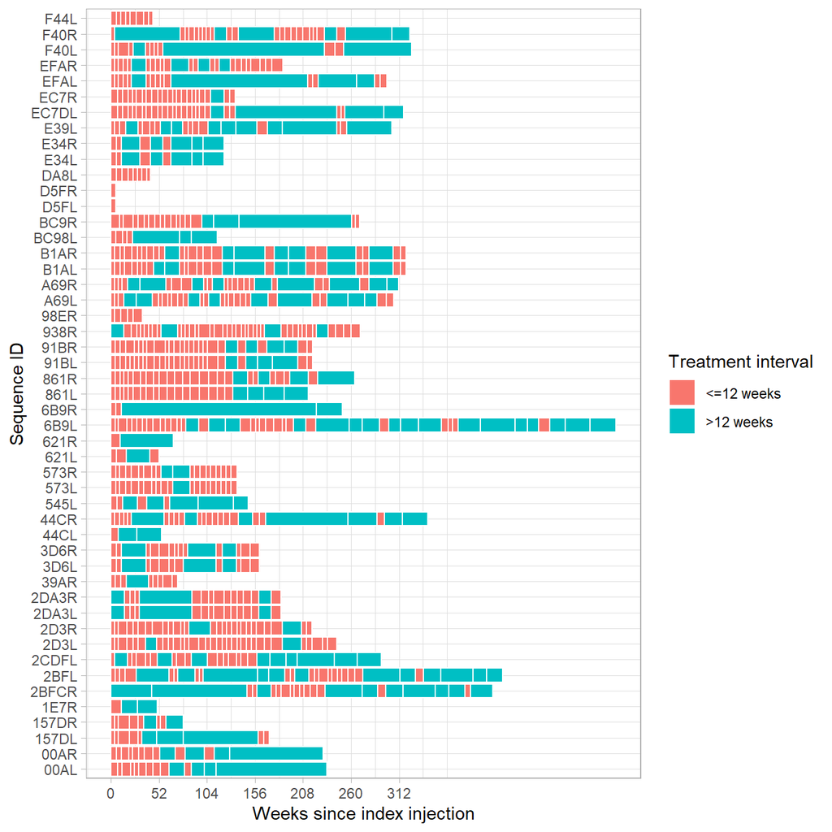

Figure 4.1: Treatment sequences for a sample of eyes.